# **Computer Assignment 4**

### *Problem Description*

*In this project, the aim is to predict housing prices in Boston using machine learning techniques such as linear regression, decision trees, K-Nearest Neighbors (KNN), and Support Vector Machines (SVM).*

### *Goal*

*The goal is to understand and implement various machine learning techniques for predicting housing prices in Boston, including data analysis, preprocessing, model creation, and evaluation.*

### *Imports*

```python
import pandas as pd
import numpy as np
import matplotlib.pyplot as plt
import seaborn as sns
import math
from sklearn import tree
from sklearn import metrics
from sklearn.model_selection import GridSearchCV , RandomizedSearchCV
from sklearn.preprocessing import StandardScaler, MinMaxScaler
from sklearn.preprocessing import LabelEncoder
from sklearn.impute import KNNImputer
from sklearn.model_selection import train_test_split
from sklearn.tree import DecisionTreeClassifier, plot_tree
from sklearn.neighbors import KNeighborsClassifier
from sklearn.ensemble import RandomForestClassifier
from xgboost import XGBClassifier
from sklearn.svm import SVC
from sklearn.metrics import accuracy_score, precision_score, recall_score, f1_score
pd.options.mode.chained_assignment = None
```

### *Constants*

```python
CSV_FILE_PATH = "DataSet.csv"
CORR_THRESHOLD = 0.3
sns.set(style="whitegrid")
sns.set_style("ticks")
```

## *Exploratory Data Analysis*

#### *Utilizing Info and Describe Methods:*

```python
data = pd.read_csv(CSV_FILE_PATH)
```

*In the dataset:*

*There are 506 entries and 14 columns.* *Most columns have complete data, except for CHAS, DIS, B, and MEDV, which have some missing values. Data types include float64 for most columns and int64 for the RAD column. The columns represent various features related to housing in Boston, such as crime rate, land zoning, air pollution levels, room count, age of properties, accessibility to highways, property tax rates, demographic information, and median home values.*

```python
data.info()
```

```
<class 'pandas.core.frame.DataFrame'>
RangeIndex: 506 entries, 0 to 505
Data columns (total 14 columns):
 #   Column   Non-Null Count  Dtype
---  ------   --------------  -----
 0   CRIM     506 non-null    float64
 1   ZN       506 non-null    float64
 2   INDUS    506 non-null    float64
 3   CHAS     480 non-null    float64
 4   NOX      506 non-null    float64
 5   RM       506 non-null    float64
 6   AGE      506 non-null    float64
 7   DIS      479 non-null    float64
 8   RAD      506 non-null    int64
 9   TAX      506 non-null    float64
 10  PTRATIO  506 non-null    float64
 11  B        486 non-null    float64
 12  LSTAT    506 non-null    float64
 13  MEDV     452 non-null    float64
dtypes: float64(13), int64(1)
memory usage: 55.5 KB
```

```python
data.head(10)
```

|  | CRIM | ZN | INDUS | CHAS | NOX | RM | AGE | DIS | RAD | TAX | PTRATIO | B | LSTAT | MEDV |
| --- | --- | --- | --- | --- | --- | --- | --- | --- | --- | --- | --- | --- | --- | --- |
| 0 | 0.00632 | 18.0 | 2.31 | 0.0 | 0.538 | 6.575 | 65.2 | 4.0900 | 1 | 296.0 | 15.3 | 396.90 | 4.98 | 24.0 |
| 1 | 0.02731 | 0.0 | 7.07 | 0.0 | 0.469 | 6.421 | 78.9 | 4.9671 | 2 | 242.0 | 17.8 | 396.90 | 9.14 | 21.6 |
| 2 | 0.02729 | 0.0 | 7.07 | 0.0 | 0.469 | 7.185 | 61.1 | 4.9671 | 2 | 242.0 | 17.8 | 392.83 | 4.03 | 34.7 |
| 3 | 0.03237 | 0.0 | 2.18 | 0.0 | 0.458 | 6.998 | 45.8 | 6.0622 | 3 | 222.0 | 18.7 | NaN | 2.94 | 33.4 |
| 4 | 0.06905 | 0.0 | 2.18 | 0.0 | 0.458 | 7.147 | 54.2 | 6.0622 | 3 | 222.0 | 18.7 | 396.90 | 5.33 | 36.2 |
| 5 | 0.02985 | 0.0 | 2.18 | 0.0 | 0.458 | 6.430 | 58.7 | 6.0622 | 3 | 222.0 | 18.7 | 394.12 | 5.21 | 28.7 |
| 6 | 0.08829 | 12.5 | 7.87 | 0.0 | 0.524 | 6.012 | 66.6 | 5.5605 | 5 | 311.0 | 15.2 | 395.60 | 12.43 | 22.9 |
| 7 | 0.14455 | 12.5 | 7.87 | 0.0 | 0.524 | 6.172 | 96.1 | 5.9505 | 5 | 311.0 | 15.2 | 396.90 | 19.15 | 27.1 |
| 8 | 0.21124 | 12.5 | 7.87 | 0.0 | 0.524 | 5.631 | 100.0 | 6.0821 | 5 | 311.0 | 15.2 | 386.63 | 29.93 | 16.5 |
| 9 | 0.17004 | 12.5 | 7.87 | 0.0 | 0.524 | 6.004 | 85.9 | 6.5921 | 5 | 311.0 | 15.2 | 386.71 | 17.10 | 18.9 |

*The describe() method generates statistical summaries of the numerical columns in the dataset. It provides key statistics such as the count of non-null values, mean, standard deviation, minimum, maximum, and quartiles.*

```python
data.describe()
```

|  | CRIM | ZN | INDUS | CHAS | NOX | RM | AGE | DIS | RAD | TAX | PTRATIO | B | LSTAT | MEDV |
| --- | --- | --- | --- | --- | --- | --- | --- | --- | --- | --- | --- | --- | --- | --- |
| count | 506.000000 | 506.000000 | 506.000000 | 480.000000 | 506.000000 | 506.000000 | 506.000000 | 479.000000 | 506.000000 | 506.000000 | 506.000000 | 486.000000 | 506.000000 | 452.000000 |
| mean | 1.269195 | 13.295257 | 9.205158 | 0.175000 | 1.101175 | 15.679800 | 58.744660 | 6.211663 | 78.063241 | 339.317787 | 42.614980 | 336.820947 | 11.537806 | 23.750442 |
| std | 2.399207 | 23.048697 | 7.169630 | 0.380364 | 1.646991 | 27.220206 | 33.104049 | 6.527286 | 203.542157 | 180.670077 | 87.585243 | 121.174519 | 6.064932 | 8.808602 |
| min | 0.000000 | 0.000000 | 0.000000 | 0.000000 | 0.385000 | 3.561000 | 1.137000 | 1.129600 | 1.000000 | 20.200000 | 2.600000 | 0.320000 | 1.730000 | 6.300000 |
| 25% | 0.049443 | 0.000000 | 3.440000 | 0.000000 | 0.449000 | 5.961500 | 32.000000 | 2.425900 | 4.000000 | 254.000000 | 17.000000 | 370.415000 | 6.877500 | 18.500000 |
| 50% | 0.144655 | 0.000000 | 6.960000 | 0.000000 | 0.538000 | 6.322500 | 65.250000 | 3.917500 | 5.000000 | 307.000000 | 18.900000 | 390.885000 | 10.380000 | 21.950000 |
| 75% | 0.819623 | 18.100000 | 18.100000 | 0.000000 | 0.647000 | 6.949000 | 89.975000 | 6.341400 | 24.000000 | 403.000000 | 20.200000 | 395.630000 | 15.015000 | 26.600000 |
| max | 9.966540 | 100.000000 | 27.740000 | 1.000000 | 7.313000 | 100.000000 | 100.000000 | 24.000000 | 666.000000 | 711.000000 | 396.900000 | 396.900000 | 34.410000 | 50.000000 |

#### *Number and percentage of missing values:*

```python
def missing_values(data):
    nan_values_count = data.isna().sum()
    nan_values_percent = nan_values_count / len(data)
    return pd.concat([nan_values_count, nan_values_percent * 100], axis=1, keys=["Missing", "Percentage"]).round(3)

missing_values(data)
```

|  | Missing | Percentage |
| --- | --- | --- |
| CRIM | 0 | 0.000 |
| ZN | 0 | 0.000 |
| INDUS | 0 | 0.000 |
| CHAS | 26 | 5.138 |
| NOX | 0 | 0.000 |
| RM | 0 | 0.000 |
| AGE | 0 | 0.000 |
| DIS | 27 | 5.336 |
| RAD | 0 | 0.000 |
| TAX | 0 | 0.000 |
| PTRATIO | 0 | 0.000 |
| B | 20 | 3.953 |
| LSTAT | 0 | 0.000 |
| MEDV | 54 | 10.672 |

#### *Unique values for each feature:*

*This process helps understand the variety within each data category.*

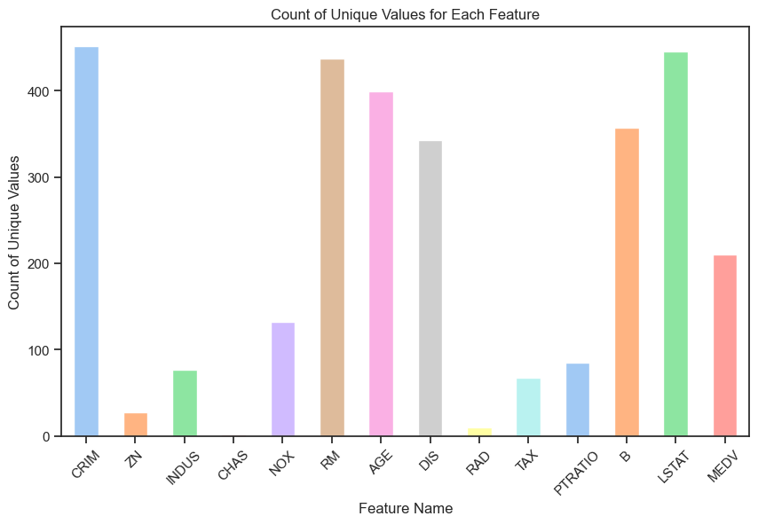

```python
unique_value_counts = data.nunique()
plt.figure(figsize=(10,6))
palette = sns.color_palette("pastel", len(unique_value_counts))
unique_value_counts.plot(kind='bar', color=palette)
plt.title('Count of Unique Values for Each Feature')
plt.xlabel('Feature Name')
plt.ylabel('Count of Unique Values')
plt.xticks(rotation=45)
plt.show()
```

#### *Plotting the correlation graph between the features.*

*Correlation is a statistical measure indicating the relationship between two variables. It can be positive (both variables increase together), negative (one variable increases while the other decreases), or zero (no apparent relationship). The strength of correlation is measured by the correlation coefficient, ranging from -1 (perfect negative correlation) to 1 (perfect positive correlation), with 0 indicating no correlation.*

*Correlation manifests as positive, negative, or zero. A positive correlation implies that an increase in one variable corresponds to an increase in the other. Conversely, a negative correlation signifies that an increase in one variable aligns with a decrease in the other. A zero correlation denotes the absence of a discernible relationship between the two variables.*

$$corr(x,y) = \frac{n\sum\limits_{i=1}^n x_i y_i - \sum\limits_{i=1}^n x_i \sum\limits_{i=1}^n y_i}{\sqrt{(n\sum\limits_{i=1}^n x_i^2 - (\sum\limits_{i=1}^n x_i)^2)(n\sum\limits_{i=1}^n y_i^2 - (\sum\limits_{i=1}^n y_i)^2)}}$$

- *n is the number of observations*
- *x is the first variable*
- *y is the second variable*

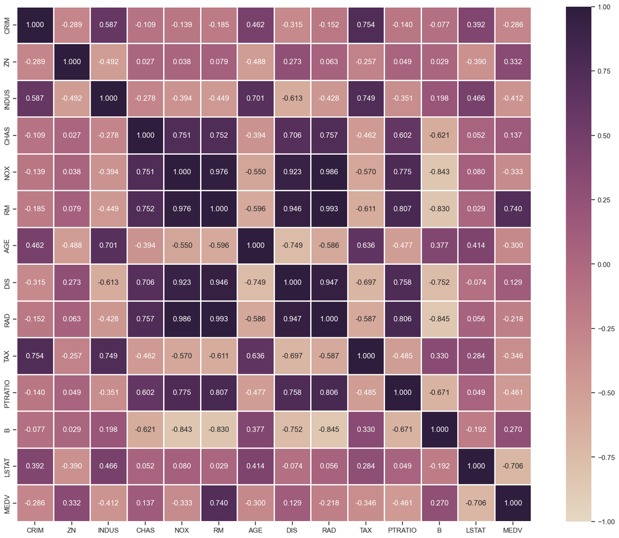

```python
data_corr = data.corr(numeric_only=True)
plt.figure(figsize=(20, 15))
sns.heatmap(data_corr, annot=True, fmt=".3f", cmap = sns.color_palette("ch:s=0 ,r=.5", as_cmap=True), linewidths=1, square=True, center=0, vmax=1, vmin=-1)
plt.show()
```

*It is evident that the features "RM" and "LSTAT" exhibit the highest correlation with the target variable.*

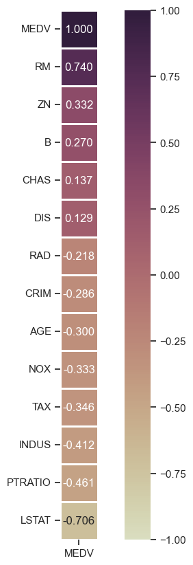

```python
MEDV_corr = data_corr[['MEDV']].sort_values(by="MEDV",ascending=False)
plt.figure(figsize=(10,10))
sns.heatmap(MEDV_corr, annot=True, fmt=".3f", cmap=sns.color_palette("ch:s=0,r=.6", as_cmap=True), linewidths=1, square=True, center=0, vmax=1, vmin=-1)
plt.show()
```

*we filter out the features with correlation coefficients above a predefined threshold:*

```python
corr_arr = data_corr['MEDV'].drop('MEDV').sort_values(ascending=False)
dependent_to_target = corr_arr[abs(corr_arr) > CORR_THRESHOLD]

dependent_to_target
```

```
RM         0.740181
ZN         0.331570
NOX       -0.332778
TAX       -0.345898
INDUS     -0.411915
PTRATIO   -0.461214
LSTAT     -0.706255
Name: MEDV, dtype: float64
```

#### *Exploring Feature Relationships: Hexbin and Scatter Plots*

*Scatter and hexbin plots serve as valuable tools for exploring relationships between features, particularly when examining their dependencies on the target column.*

*`Scatter Plot:`*

- ***Functionality*** *: A scatter plot displays individual data points on a two-dimensional Cartesian plane, with one variable plotted on the x-axis and another on the y-axis.*
- ***Usage*** *: It provides a visual representation of the relationship between two variables, making it easy to identify patterns, trends, or outliers. By plotting the target variable against a feature, we can visually assess the nature and strength of their relationship. For example, in the context of housing data, plotting the number of rooms (RM) against the median house value (MEDV) using a scatter plot allows us to observe if there's a linear or non-linear correlation between the two variables.*

*`Hexbin Plot:`*

- ***Functionality*** *: A hexbin plot is similar to a scatter plot, but it aggregates data points into hexagonal bins, providing a more structured representation of the data distribution.*
- ***Usage*** *: This type of plot is particularly useful when dealing with large datasets, as it helps in visualizing the density of data points within different regions of the plot. By representing the counts of data points within each hexagonal bin with varying colors or shades, hexbin plots offer insights into the density and distribution of data. When examining the relationship between a feature and the target variable, a hexbin plot can reveal any concentration of data points and highlight regions of high or low density, indicating the strength and nature of the relationship more clearly.*

*Both scatter and hexbin plots facilitate the exploration of feature-target dependencies by visually representing the correlation and distribution of data. While scatter plots provide a straightforward depiction of individual data points, hexbin plots offer a more structured view, especially beneficial for large datasets, by summarizing data density within hexagonal bins.*

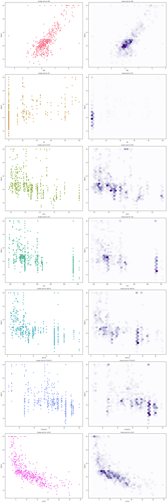

```python
colors = sns.color_palette("husl", len(dependent_to_target.index))

fig, axs = plt.subplots(nrows=len(dependent_to_target.index), ncols=2, figsize=(20, 60))

for i, (feature, color) in enumerate(zip(dependent_to_target.index, colors)):
    axs[i, 0].scatter(data[feature], data["MEDV"], color=color)
    axs[i, 0].set_title(f'Scatter plot for {feature}')
    axs[i, 0].set_xlabel(feature)
    axs[i, 0].set_ylabel("MEDV")

    axs[i, 1].hexbin(data[feature], data["MEDV"], gridsize=30, cmap='Purples')
    axs[i, 1].set_title(f'Hexbin plot for {feature}')
    axs[i, 1].set_xlabel(feature)
    axs[i, 1].set_ylabel("MEDV")

plt.tight_layout()
plt.show()
```

### *Question 6: Alternative Approaches for Dataset Analysis*

*A box plot, or box-and-whisker plot, is a statistical visualization method that presents a summary of the distribution of numerical data. The box in the plot represents the interquartile range (IQR), with the median value indicated by a line inside the box. The whiskers extend from the box to the minimum and maximum values within a specified range, typically 1.5 times the IQR. Outliers, which fall outside this range, are plotted individually. Box plots provide a clear visual representation of the central tendency, spread, and presence of outliers in the dataset, making them valuable tools for data exploration and comparison between different groups or variables.*

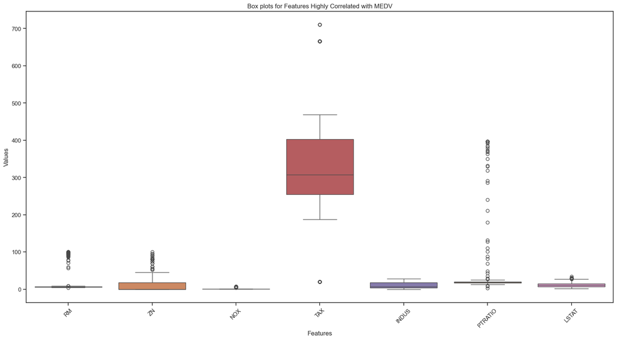

```python
features_to_plot = dependent_to_target.index
plt.figure(figsize=(20, 10))
sns.boxplot(data=data[features_to_plot])
plt.title('Box plots for Features Highly Correlated with MEDV')
plt.xticks(rotation=45)
plt.xlabel('Features')
plt.ylabel('Values')
plt.show()
```

*A violin plot is a statistical visualization that combines elements of a box plot and a kernel density plot to display the distribution and density of numeric data. It presents a summary of the data's distribution, including key statistics such as the median, quartiles, and range, similar to a box plot. Additionally, the width of the "violin" shape at each point along the vertical axis represents the density of data points, offering insights into the concentration of values within the dataset. This visualization is particularly useful for comparing the distributions of multiple variables or groups, aiding in the analysis of data distribution and variability.*

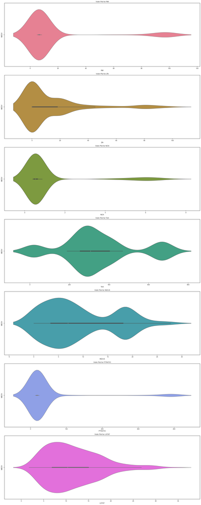

```python
plt.figure(figsize=(20, 50))
colors = sns.color_palette("husl", len(dependent_to_target.index))
for i, (feature, color) in enumerate(zip(dependent_to_target.index, colors)):

    plt.subplot(len(dependent_to_target.index), 1, i+1)
    sns.violinplot(x=data[feature], color=color)
    plt.title(f'Violin Plot for {feature}')
    plt.xlabel(feature)
    plt.ylabel("MEDV")

plt.tight_layout()
plt.show()
```

## *Preprocessing*

### *Handling Missing Values Mthodes*

#### *`Imputation:`*

*One commonly employed approach is mean imputation, wherein absent values are substituted with the mean of the available data. Likewise, the median and mode of the non-missing data may serve as alternatives. Another strategy involves replacing missing values with the preceding or subsequent observation's value, referred to as forward-fill and backward-fill, respectively. Alternatively, one may opt to predict missing values or introduce a randomly selected value into the dataset.*

- ***`Filling with Mean:`*** *Using the average to fill missing values is simple to do and the mean is a good representative of the data as a whole.But sometimes it may not make sense and be impossible to use for a column.*
- ***`Filling with Median:`***  
  *The outlier data can affect the mean negatively.In such cases, it may be better to use the median which is not affected by outliers.*
- ***`Filling with Mode:`*** *Mean and median do not work with categorical data.Using the mode can be a alternative for such data.*
- ***`Random Fill:`***  
  *In this method we fill using random values, mostly in the range of the column's minimum and maximum data, or between the categories.*
- ***`Predicting:`***  
  *A more advanced method is to have a way of predicting what the missing value should be based on the other properties of the row.*
- ***`Forward-fill and Backward-fill:`***  
  *In this method we fill the missing values with next or previous observation respectively*

#### *`Dropping:`*

*An alternative is to eliminate observations that include missing values. This decision should be approached thoughtfully, as it has the potential to diminish the dataset's size and influence its representativeness. There are two primary methods for this: eliminating columns or eliminating rows.*

- ***`Dropping Columns:`***  
  *In this method we remove any column that has missing values in it. This is usually not wanted because we potentially losing a lot of data.This method should only be considered on columns that have too many missing values; and in fact, its actually the better thing to do in such cases because there is not much data to fill it with good precision.*
- ***`Dropping Rows:`***  
  *Works similarly to dropping columns.If we remove all rows that have missing values, if a column is all missing, then all of the rows will be gone.This method should also only be considered on rows that have most of their properties missing.*

*Ultimately, in instances where missing data is minimal, one may opt to disregard these values entirely and proceed with the analysis. Nevertheless, it is crucial to ascertain whether the missingness is random or non-random before making this decision.*

```python
data_backup1 = data
data_backup2 = data
```

1. *I have choosen to use `Filling with median` becuase this is to not get affected by outliers and also not be fractional.*

```python
data.fillna(data.median(numeric_only=True), inplace=True)
missing_values(data)
```

|  | Missing | Percentage |
| --- | --- | --- |
| CRIM | 0 | 0.0 |
| ZN | 0 | 0.0 |
| INDUS | 0 | 0.0 |
| CHAS | 0 | 0.0 |
| NOX | 0 | 0.0 |
| RM | 0 | 0.0 |
| AGE | 0 | 0.0 |
| DIS | 0 | 0.0 |
| RAD | 0 | 0.0 |
| TAX | 0 | 0.0 |
| PTRATIO | 0 | 0.0 |
| B | 0 | 0.0 |
| LSTAT | 0 | 0.0 |
| MEDV | 0 | 0.0 |

2. *Replace missing values with the mean/median value of K nearest neighbors based on other features.*

```python
imputer = KNNImputer(n_neighbors=5)
data_imputed = pd.DataFrame(imputer.fit_transform(data_backup1), columns=data_backup1.columns)
missing_values(data_imputed)
```

|  | Missing | Percentage |
| --- | --- | --- |
| CRIM | 0 | 0.0 |
| ZN | 0 | 0.0 |
| INDUS | 0 | 0.0 |
| CHAS | 0 | 0.0 |
| NOX | 0 | 0.0 |
| RM | 0 | 0.0 |
| AGE | 0 | 0.0 |
| DIS | 0 | 0.0 |
| RAD | 0 | 0.0 |
| TAX | 0 | 0.0 |
| PTRATIO | 0 | 0.0 |
| B | 0 | 0.0 |
| LSTAT | 0 | 0.0 |
| MEDV | 0 | 0.0 |

3. *Propagate non-missing values forward or backward to fill missing values.*

```python
data_backup2.ffill(inplace=True)
missing_values(data_backup2)
```

|  | Missing | Percentage |
| --- | --- | --- |
| CRIM | 0 | 0.0 |
| ZN | 0 | 0.0 |
| INDUS | 0 | 0.0 |
| CHAS | 0 | 0.0 |
| NOX | 0 | 0.0 |
| RM | 0 | 0.0 |
| AGE | 0 | 0.0 |
| DIS | 0 | 0.0 |
| RAD | 0 | 0.0 |
| TAX | 0 | 0.0 |
| PTRATIO | 0 | 0.0 |
| B | 0 | 0.0 |
| LSTAT | 0 | 0.0 |
| MEDV | 0 | 0.0 |

### *Question 8: dropping colomns*

```python
data.columns
```

```
Index(['CRIM', 'ZN', 'INDUS', 'CHAS', 'NOX', 'RM', 'AGE', 'DIS', 'RAD', 'TAX',
       'PTRATIO', 'B', 'LSTAT', 'MEDV'],
      dtype='object')
```

*I've selectively removed several columns from the dataset because they demonstrated minimal correlation with the target variable, thereby focusing the analysis on the most relevant features.*

```python
data = data[dependent_to_target.index.union(["MEDV"])]
data.columns
```

```
Index(['INDUS', 'LSTAT', 'MEDV', 'NOX', 'PTRATIO', 'RM', 'TAX', 'ZN'], dtype='object')
```

### *Question 9: numerical vs categorial features*

*In the dataset, numerical features are those that represent quantitative data and can be measured or expressed as numbers. Categorical features, on the other hand, represent qualitative data and consist of distinct categories or groups.*

*The main difference between numerical and categorical features lies in their nature and the type of information they represent. Numerical features typically have a continuous range of values and can be subjected to mathematical operations such as addition, subtraction, and averaging. Categorical features, however, represent discrete categories or groups and do not have a natural ordering or numerical significance. In this dataset, numerical features include various housing-related metrics, while the only categorical feature is related to the proximity of the town to the Charles River. although it represnted numerical in the dataset*

### *Question 10: Normalize and Standardize*

*`Normalizing`: Normalizing is the process of scaling the values of a column to a range between 0 and 1. This is done by subtracting the minimum value of the column from each value, and then dividing by the range of the column (i.e., the difference between the maximum and minimum values). Normalizing is useful when the absolute values of the data are not important, but the relative values are. We can use the `MinMaxScaler` method to do this. We can't use normalization when we are not using algorithms such as `KNN` or `Neural Networks` which are based on distance. Below is the formula for the `MinMaxScaler` method:*

$$X_{norm} = \frac{X - X_{min}}{X_{max} - X_{min}}$$

*`Standardizing`: Standardizing is the process of scaling the values of a column to have a mean of 0 and a standard deviation of 1. This is done by subtracting the mean of the column from each value, and then dividing by the standard deviation of the column. Standardizing is useful when the absolute values of the data are important, and when the data has a normal distribution. Below is the formula for the `StandardScaler` method:*

$$X_{std} = \frac{X - \mu}{\sigma}$$

*why do we need them:*

- *`Different scales`: The features in a DataFrame may have different scales, which can cause some features to dominate the others in the analysis. For example, if one feature has values in the range of 0-1 and another feature has values in the range of 0-1000, the second feature will have a much larger impact on the analysis. Normalizing or standardizing the data can ensure that all features have a similar scale and prevent this issue.*
- *`Outliers`: Outliers in the data can also have a significant impact on the analysis. Normalizing or standardizing the data can reduce the impact of outliers by scaling the data to a more reasonable range.*
- *`Algorithm requirements`: Some machine learning algorithms require the data to be normalized or standardized in order to work properly. For example, algorithms that use distance measures, such as k-nearest neighbors or clustering algorithms, can be sensitive to the scale of the data. Normalizing or standardizing the data can ensure that these algorithms work properly.*
- *`Interpretability`: Normalizing or standardizing the data can make the results of the analysis more interpretable. For example, if the data is standardized to have a mean of 0 and a standard deviation of 1, the coefficients of a linear regression model will represent the change in the response variable for a one standard deviation change in the predictor variable.*

```python
def standardization(data: pd.DataFrame, exclude_cols: list = []):
    scaler_std = StandardScaler()
    numeric_cols = data.drop(columns = exclude_cols).select_dtypes(include="number")
    data[numeric_cols.columns] = scaler_std.fit_transform(numeric_cols)

def normalization(data: pd.DataFrame, exclude_cols: list = []):
    scaler_norm = MinMaxScaler()
    numeric_cols = data.drop(columns = exclude_cols).select_dtypes(include="number")
    data[numeric_cols.columns] = scaler_norm.fit_transform(numeric_cols)
```

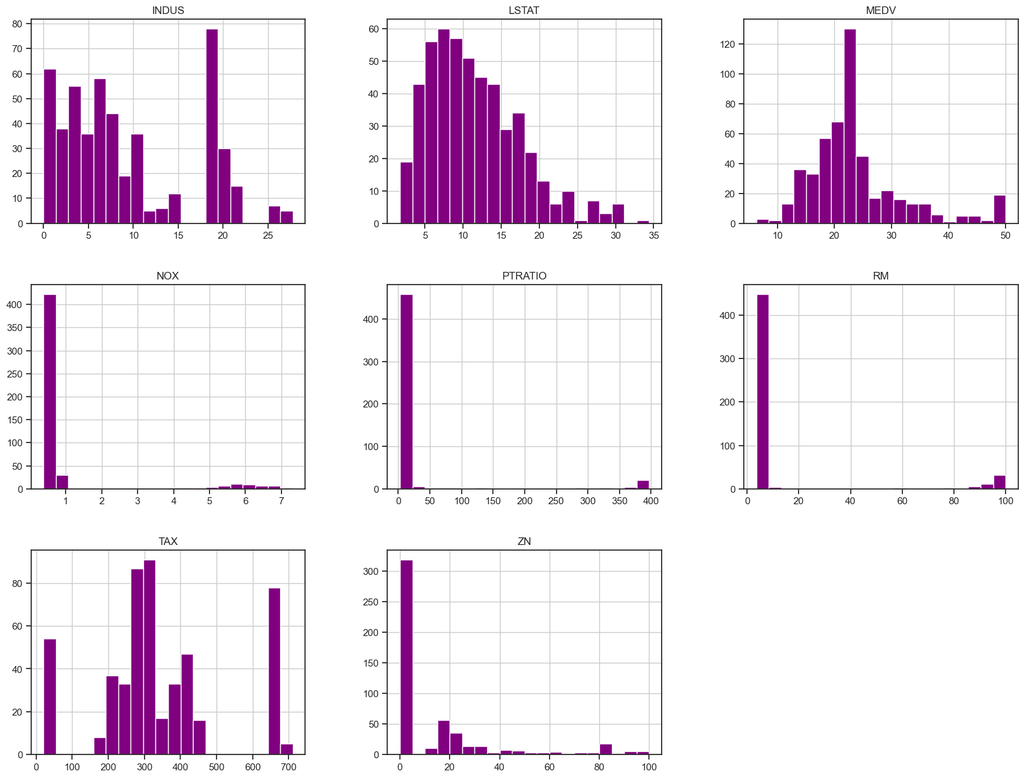

```python
data.hist(bins=20, figsize=(20,15), color='purple')
plt.show()
```

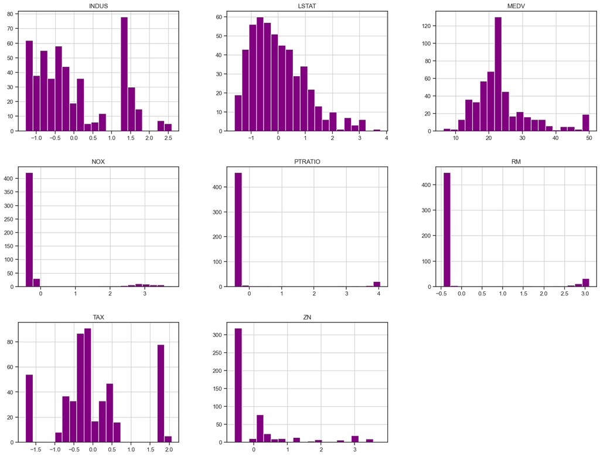

```python
normalization(data, ["MEDV"])
standardization(data, ["MEDV"])
data.hist(bins=20, figsize=(20,15),color = 'Purple')
plt.show()
```

### *Question 11: Encoding Categorical Values*

- *`Label Encoding`: This method assigns a unique integer label to each category in the data. This is useful when the categories have an inherent order or ranking, such as low, medium, and high. The LabelEncoder class from the sklearn.preprocessing module can be used to perform label encoding.*

  > Category 1: 0  
  > Category 2: 1  
  > Category 3: 2
- *`One-Hot Encoding`: This method creates a binary column for each category in the data, indicating whether the category is present or not. This is useful when the categories do not have an inherent order or ranking, and when the number of categories is small. The get_dummies() function from Pandas can be used to perform one-hot encoding.*

  > Category 1: 1, 0, 0  
  > Category 2: 0, 1, 0  
  > Category 3: 0, 0, 1
- *`Binary Encoding`: This method creates binary columns for each category in the data, but instead of using a single binary column for each category, it uses a binary code for each category. This is useful when the number of categories is large, as it reduces the number of columns needed for encoding. The BinaryEncoder class from the category_encoders library can be used to perform binary encoding.*

  > Category 1: 00  
  > Category 2: 01  
  > Category 3: 10
- *`Count Encoding`: This method replaces each category in the data with the number of times it appears in the dataset. This is useful when the frequency of each category is important, and when the number of categories is large. The CountEncoder class from the category_encoders library can be used to perform count encoding.*

  > Category 1: 0.5  
  > Category 2: 0.25  
  > Category 3: 0.25
- *`Target Encoding`: This method replaces each category in the data with the mean of the target variable for that category. This is useful when the relationship between the categories and the target variable is important, and when the number of categories is large. The TargetEncoder class from the category_encoders library can be used to perform target encoding.*

  > Category 1: 0.5  
  > Category 2: 0.25  
  > Category 3: 0.75
- *`Hash Encoding`: Hash encoding applies a hashing function to map categories to a fixed number of values. It reduces the dimensionality of the feature space but may introduce collisions.*
- *`Text Encoding`: Categorical features are often stored as text. Before using them in model training, you can convert these texts into numerical representations such as TF-IDF vectors or Word2Vec embeddings.*

### *Question 12: Test and Train and Validation data*

*`Training Set`: This subset of the data is used to train the machine learning model. The model learns patterns and relationships from the input features and their corresponding target variables (labels) in the training set.*

*`Validation Set`: The validation set is used to evaluate the performance of the model during training. It helps in tuning hyperparameters and selecting the best model architecture by providing an unbiased estimate of the model's performance on unseen data. This subset is crucial for preventing overfitting.*

*`Test Set`: The test set is used to assess the final performance of the trained model. It provides an unbiased evaluation of the model's performance on completely unseen data. The test set is used only after the model is trained and tuned using the training and validation sets.*

*Common Data Splitting Methods:*

- *Holdout Method: In this method, the dataset is split into two subsets: typically a larger portion for training and a smaller portion for testing. The holdout method is simple and commonly used when you have a sufficient amount of data.*
- *K-Fold Cross-Validation: In k-fold cross-validation, the dataset is divided into k equal-sized folds. The model is trained k times, each time using k-1 folds for training and the remaining fold for validation. The performance scores are averaged across all folds to obtain a final performance estimate.*
- *Stratified Sampling: Stratified sampling ensures that each subset (training, validation, or test) contains a proportionate representation of the target classes. This is particularly useful for imbalanced datasets where some classes are underrepresented.*

```python
features = data.drop("MEDV", axis = "columns")
X_train, X_test, y_train, y_test = train_test_split(features, data["MEDV"], test_size=0.2, random_state=42)
X_train, X_val, y_train, y_val = train_test_split(X_train, y_train, test_size=0.2, random_state=42)
```

```python
display(X_train.head(10))
```

|  | INDUS | LSTAT | NOX | PTRATIO | RM | TAX | ZN |
| --- | --- | --- | --- | --- | --- | --- | --- |
| 54 | -0.726719 | 0.538410 | -0.420075 | -0.245889 | -0.360081 | 0.718495 | 2.679796 |
| 28 | -0.148712 | 0.208319 | -0.342280 | -0.247032 | -0.337760 | -0.179054 | -0.577404 |
| 423 | 1.241856 | 1.939646 | -0.296090 | -0.256175 | -0.352175 | 1.809959 | -0.577404 |
| 244 | -0.467035 | 0.158806 | -0.407312 | -0.268747 | -0.370930 | -0.051625 | 0.378041 |
| 111 | 0.112368 | -0.227401 | -0.336811 | -0.283604 | -0.329670 | 0.513499 | -0.577404 |
| 228 | -0.419566 | -1.257285 | -0.362945 | -0.288176 | -0.293962 | -0.179054 | -0.577404 |
| 80 | -0.606650 | -1.031172 | -0.410351 | -0.269890 | -0.329228 | -0.323106 | 0.508329 |
| 29 | -0.148712 | 0.072982 | -0.342280 | -0.247032 | -0.331177 | -0.179054 | -0.577404 |
| 309 | 0.097011 | -0.258759 | -0.338634 | -0.276747 | -0.356992 | -0.195676 | -0.577404 |
| 352 | -1.049231 | -0.618559 | -0.419467 | -0.277890 | -0.360229 | 0.397150 | 2.028356 |

```python
display(X_val.head(10))
```

|  | INDUS | LSTAT | NOX | PTRATIO | RM | TAX | ZN |
| --- | --- | --- | --- | --- | --- | --- | --- |
| 37 | -0.453074 | -0.456814 | -0.365983 | -0.267604 | -0.361479 | -0.334186 | -0.577404 |
| 107 | -0.090074 | 0.421228 | -0.353220 | -0.248175 | -0.351292 | 0.247559 | -0.577404 |
| 130 | 1.770997 | 0.175310 | -0.290012 | -0.244746 | -0.339120 | 0.541201 | -0.577404 |
| 432 | 1.241856 | 0.081234 | -0.314323 | -0.256175 | -0.340334 | 1.809959 | -0.577404 |
| 404 | -1.285180 | -0.501376 | 2.692310 | 3.278279 | 2.563875 | -1.768049 | 0.208667 |
| 272 | -0.313458 | -0.628461 | -0.387255 | -0.274461 | -0.336178 | -0.644450 | 0.291183 |
| 341 | -1.072965 | -0.998163 | -0.400626 | -0.309890 | -0.310327 | -0.306484 | 0.942623 |
| 263 | -0.730908 | -0.047501 | -0.276034 | -0.338462 | -0.307164 | -0.417293 | 0.291183 |
| 58 | -0.568954 | -0.772051 | -0.393941 | -0.261890 | -0.350631 | -0.306484 | 0.508329 |
| 61 | -0.568954 | 0.478994 | -0.393941 | -0.261890 | -0.357213 | -0.306484 | 0.508329 |

```python
X_train, X_test, y_train, y_test = train_test_split(features, data["MEDV"], test_size=0.2, random_state=42)
```

### *Question 13: Other Preprocessing Techniques.*

*Data preprocessing involves several key steps to prepare raw data for machine learning tasks. Firstly, data cleaning is performed to handle missing and noisy data. Missing data can be addressed by either ignoring the tuples or filling in missing values using methods like mean imputation or regression. Noisy data, which is meaningless and error-prone, can be smoothed out using techniques such as binning, regression, or clustering. Secondly, data transformation is applied to convert the data into appropriate forms for mining. This includes normalization to scale data values, attribute selection to construct new attributes, discretization to replace numeric values with intervals, and concept hierarchy generation to organize attributes hierarchically. Lastly, data reduction techniques are employed to reduce dataset size while preserving important information. This involves feature selection to choose relevant features, feature extraction to transform data into a lower-dimensional space, sampling to select a subset of data points, clustering to group similar data points, and compression to reduce dataset size for storage and transmission. These preprocessing steps are essential for improving the efficiency and effectiveness of data analysis and machine learning models.By employing these preprocessing techniques judiciously based on dataset characteristics and task requirements, machine learning models can achieve better performance and robustness.*

# *Training, Testing and Evaluating the Models.*

## *Linear Regression*

### *Question 14: Supervised vs Unsupervised, Semi-Supervised, and Reinforcement Learning*

*`Supervised learning` models rely on labeled data to make predictions or decisions. The key difference between supervised learning and other types of learning paradigms lies in the availability of labeled data for training. In supervised learning, the algorithm learns from input-output pairs provided by a supervisor, enabling it to make predictions or decisions based on new, unseen data.*

- *Example: In a supervised learning scenario, a spam email classifier is trained on a dataset where each email is labeled as either spam or not spam. The algorithm learns to distinguish between spam and non-spam emails based on features such as keywords, sender, and email content.*

`Unsupervised learning` models deal with unlabeled data, aiming to find hidden patterns or structures within the data.

- *Example: An unsupervised learning application could be customer segmentation in marketing, where clustering algorithms are used to group customers based on similar characteristics.*

*`Semi-supervised learning` combines elements of both supervised and unsupervised learning, utilizing a small amount of labeled data along with a larger pool of unlabeled data.*

- *Example: In semi-supervised learning, an algorithm might use a small set of labeled images to improve the performance of a facial recognition system trained on a large set of unlabeled images.*

*`Reinforcement learning`, on the other hand, involves an agent learning to make decisions by interacting with an environment and receiving feedback in the form of rewards or penalties.*

- *Example: In reinforcement learning, an autonomous driving agent learns to navigate through traffic by receiving rewards for safe driving behaviors and penalties for accidents.*

### *Question 15: Regression vs Classification*

**`Regression`** *is a supervised learning technique used for predicting continuous values. In regression, the goal is to establish a relationship between input features and a continuous target variable, allowing the model to make predictions about the target variable's value based on new input data. Regression models aim to find the best-fitting line or curve that minimizes the difference between predicted and actual values.*

**`Classification`**,*on the other hand, is also a supervised learning technique used for predicting discrete values or labels. Unlike regression, where the target variable is continuous, classification aims to assign input data points to predefined categories or classes. The model learns to classify new instances into one of the predefined classes based on their features.*

### *Question 16: Explanation of Linear Regression Equations*

*The most common method for fitting a regression line is the method of least-squares. This method calculates the best-fitting line for the observed data by minimizing the sum of the squares of the vertical deviations from each data point to the line (if a point lies on the fitted line exactly, then its vertical deviation is 0). Because the deviations are first squared, then summed, there are no cancellations between positive and negative values.*

*Main form of simple linear regression function:* $$f(x) = \alpha x + \beta$$

*here we want to find the bias ($\alpha$) and slope($\beta$) by minimizing the derivation of the Residual Sum of Squares (RSS) function:*

- *step 1: Compute RSS of the training data*

$$ RSS = \Sigma (y_i - (\hat{\beta} + \hat{\alpha} * x_i) )^2 $$

- *step 2: Compute the derivatives of the RSS function in terms of $\alpha$ and $\beta$, and set them equal to 0 to find the desired parameters*

$$ \frac{\partial RSS}{\partial \beta} = \Sigma (-f(x_i) + \hat{\beta} + \hat{\alpha} * x_i) = 0$$$$ \to \beta = \hat{y} - \hat{\alpha} \hat{x} \to (1)$$$$ \frac{\partial RSS}{\partial \alpha} = \Sigma (-2 x_i y_i + 2 \hat{\beta} x_i + 2\hat{\alpha} x_i ^ 2) = 0 \to (2)$$$$ (1) , (2) \to \hat{\alpha} = \frac{\Sigma{(x_i - \hat{x})(y_i - \hat{y})}}{\Sigma{(x_i - \hat{x})^2}} $$$$ \hat{\beta} = y - \hat{a} x$$

```python
def simple_linear_regression(input_feature, output):
    input_mean = input_feature.mean()
    output_mean = output.mean()
    bias = ((input_feature - input_mean) * (output - output_mean)).sum() / ((input_feature - input_mean)**2).sum()
    slope = output_mean - bias * input_mean
    return (bias, slope)
```

*Now we want to predict the value of given data based on the calculated intercept and slope*

```python
def get_regression_predictions(input_feature, bias, slope):
    return input_feature * bias + slope
```

*Now that we have a model and can make predictions, let's evaluate our model using Root Mean Square Error (RMSE). RMSE is the square root of the mean of the squared differences between the residuals, and the residuals is just a fancy word for the difference between the predicted output and the true output.*

```python
def get_root_mean_square_error(predicted_values, outputs):
    residuals = predicted_values - outputs
    residuals_sum_sqr = (residuals ** 2).sum()
    mean_residual_sqr = residuals_sum_sqr/len(predicted_values)
    return math.sqrt(mean_residual_sqr)
```

*The RMSE has no bound, thus it becomes challenging to determine whether a particular RMSE value is considered good or bad without any reference point. Instead, we use R2 score. The R2 score is calculated by comparing the sum of the squared differences between the actual and predicted values of the dependent variable to the total sum of squared differences between the actual and mean values of the dependent variable. The R2 score is formulated as below:*

$$R^2 = 1 - \frac{SSres}{SStot} = 1 - \frac{\sum_{i=1}^{n} (y_{i,true} - y_{i,pred})^2}{\sum_{i=1}^{n} (y_{i,true} - \bar{y}_{true})^2} $$

*Complete the following function to calculate the R2 score of a given input_feature, output, bias, and slope:*

```python
def get_r2_score(predicted_values, outputs):
    residuals = predicted_values - outputs
    SSres = (residuals ** 2).sum()
    SStot = ((outputs - outputs.mean())**2).sum()
    return 1 - SSres / SStot
```

*Now we calculate the fitness of the model.*

```python
def test_simple_linear_regression(feature, ax):
    bias, slope = simple_linear_regression(X_train[feature], y_train)
    predicted_values = get_regression_predictions(X_test[feature], bias, slope)
    rmse = get_root_mean_square_error(predicted_values, y_test)
    r2_score = get_r2_score(predicted_values, y_test)

    print(f"{feature}:")
    print(f"RMSE: {rmse:0.3f}, R^2: {r2_score:0.3f}")
    print(f"y = {bias:0.3f} * x + {slope:0.3f}")
    print("------------------------")

    ax.scatter(X_train[feature], y_train, color='lightblue')
    x_line = np.linspace(min(X_train[feature]), max(X_train[feature]), 100)
    y_line = bias * x_line + slope
    ax.plot(x_line, y_line, color='purple', label=f"y = {bias:0.3f} * x + {slope:0.3f}")
    ax.set_ylabel("MEDV")
    ax.set_xlabel(feature)
    ax.set_title(feature)
    ax.legend()
```

```
RM:
RMSE: 7.782, R^2: -0.024
y = -0.482 * x + 23.788
------------------------
ZN:
RMSE: 6.723, R^2: 0.236
y = 2.283 * x + 23.770
------------------------
NOX:
RMSE: 7.777, R^2: -0.022
y = -0.809 * x + 23.791
------------------------
TAX:
RMSE: 7.428, R^2: 0.067
y = -1.879 * x + 23.748
------------------------
INDUS:
RMSE: 7.114, R^2: 0.145
y = -2.743 * x + 23.733
------------------------
PTRATIO:
RMSE: 7.779, R^2: -0.023
y = -0.599 * x + 23.792
------------------------
LSTAT:
RMSE: 5.550, R^2: 0.479
y = -5.599 * x + 23.712
------------------------
```

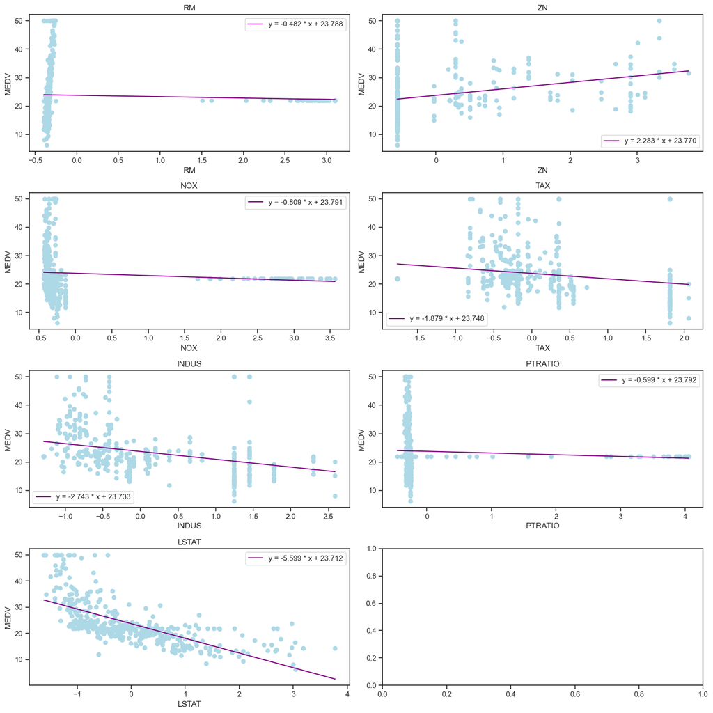

```python
designated_feature_list =  list(dependent_to_target.index)

figure, axs = plt.subplots(nrows=4, ncols=2, figsize=(15,15))
axs = axs.flatten()
for ax, feature in zip(axs, designated_feature_list):
    test_simple_linear_regression(feature, ax)

plt.tight_layout()
```

### *Question 18: methods of RSS, MSE, RMSE, and R-squared score.*

- *`Residual Sum of Squares (RSS)`: RSS is the sum of the squared differences between the actual values and the predicted values. It measures the overall discrepancy between the observed and predicted values. A lower RSS indicates a better fit of the model to the data.*
- *`Mean Squared Error (MSE)`: MSE is the average of the squared differences between the actual values and the predicted values. It provides a measure of the average squared deviation of the predictions from the actual values. Like RSS, a lower MSE indicates better model performance.*
- *`Root Mean Squared Error (RMSE)`: RMSE is the square root of the MSE. It represents the average magnitude of the residuals or prediction errors. RMSE is in the same unit as the dependent variable, making it easier to interpret. Again, a lower RMSE signifies better predictive accuracy.*
- *`R-squared (R2) Score`: R2 score measures the proportion of the variance in the dependent variable that is predictable from the independent variable(s). It ranges from 0 to 1, where 1 indicates perfect prediction and 0 indicates no linear relationship between the variables. R2 score of 1 signifies that the model explains all the variability of the response data around its mean. In contrast, an R2 score of 0 means the model does not explain any variability. Negative values can indicate that the model is worse than a model that simply predicts the mean of the target variable.*

*Each of these metrics provides valuable insights into the performance of the regression model, allowing us to assess its accuracy and suitability for the given task.*

### *Question 19: Evaluation of Predicted Values using RMSE and R-squared Score*

*we aim to assess the performance of the linear regression model using different features individually. The designated_feature_list contains a list of features sorted based on their correlation with the target variable. The function test_simple_linear_regression is then applied to each feature, where the linear regression model is trained using that specific feature, and its performance is evaluated in terms of RMSE and R-squared score.*

*By visualizing the results for each feature, we can observe how well the model performs when trained on different features individually. The choice of the "best" feature depends on which one yields the most accurate predictions, as indicated by lower RMSE and higher R-squared scores. The feature that leads to the lowest RMSE and highest R-squared score can be considered the most informative or predictive for the target variable. Therefore, by analyzing the plots generated by the code, we can identify the feature that provides the most accurate predictions and select it as the input for the regression model. This approach allows us to prioritize features that have stronger relationships with the target variable, leading to more accurate predictions.*

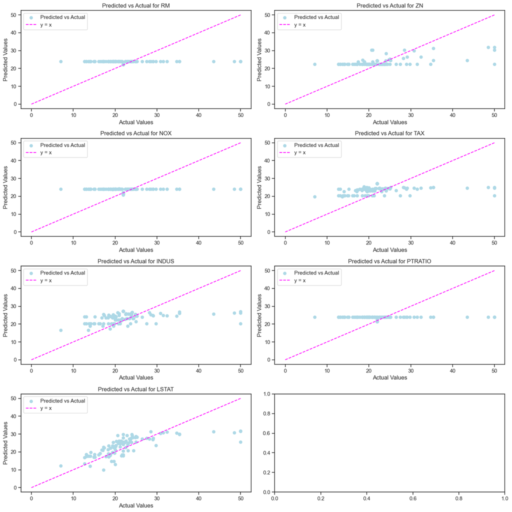

```python
def compare_predicted_actual(feature, ax):
    bias, slope = simple_linear_regression(X_train[feature], y_train)
    predicted_values = get_regression_predictions(X_test[feature], bias, slope)
    ax.scatter(y_test, predicted_values, color='lightblue', label='Predicted vs Actual')
    ax.plot([0, max(y_test)], [0, max(y_test)], color=(1.0, 0.0, 1.0), linestyle='--', label='y = x')
    ax.set_xlabel('Actual Values')
    ax.set_ylabel('Predicted Values')
    ax.set_title(f'Predicted vs Actual for {feature}')
    ax.legend()


fig, axs = plt.subplots(nrows=4, ncols=2, figsize=(15,15))
axs = axs.flatten()

for ax, feature in zip(axs, designated_feature_list):
    compare_predicted_actual(feature, ax)

plt.tight_layout()
plt.show()
```

### *Question 20: Comparing Predicted and Actual Values with Scatter Plots*

*The scatter plot for LSTAT shows a strong positive correlation between the predicted and actual values. The points are clustered closely around the y = x line, which suggests that the LSTAT feature is able to accurately capture the relationship between the input variables and the target variable.*

## *Classification*

### *Question 21: Pruning Concepts in Decision Trees*

*Pruning is a technique employed to address overfitting in decision trees. It involves selectively removing parts of the tree that do not contribute significantly to the model's predictive performance. This process aims to simplify the tree by eliminating redundant or irrelevant branches, thereby reducing the model's complexity and improving its generalization ability.*

*Two primary pruning strategies exist: pre-pruning and post-pruning.*

- *Pre-pruning, also known as early stopping, involves halting the tree-building process before it reaches its maximum depth. This approach prevents the tree from becoming overly complex and susceptible to overfitting.*
- *post-pruning involves pruning a fully grown decision tree. This strategy evaluates each node in the tree and removes those that do not improve the model's performance.*

*Advantages of Pruning Decision Trees*

1. *`Reduced Overfitting`: Pruning effectively mitigates overfitting by eliminating irrelevant branches that capture noise and unnecessary details from the training data. This enhances the model's ability to generalize to unseen data.*
2. *`Improved Model Interpretability`: Pruning simplifies the decision tree structure, making it more transparent and easier to understand. This facilitates the identification of important features and decision-making rules.*
3. *`Enhanced Model Performance`: By reducing overfitting and improving interpretability, pruning can lead to a more accurate and reliable prediction model.*

*Disadvantages of Pruning Decision Trees*

1. *`Risk of Underfitting`: Excessive pruning can lead to underfitting, where the model becomes too simplistic and fails to capture essential patterns in the data. This can result in decreased accuracy.*
2. *`Increased Computational Complexity`: Post-pruning algorithms can be computationally expensive, particularly for large and complex decision trees.*
3. *`Loss of Information`: Pruning may discard potentially useful information from the tree, potentially affecting the model's performance.*

### *Question 22: When to use Decision Trees*

*Decision trees can have an advantage over other models when the relationship between features and the target variable is non-linear or when dealing with categorical variables. They are also interpretable and can handle missing values without requiring extensive preprocessing. Additionally, decision trees are less sensitive to feature scaling and can handle irrelevant features well, making them suitable for datasets with a mix of relevant and irrelevant attributes. However, they may suffer from overfitting on noisy data or data with many features, which can be mitigated using ensemble methods like Random Forests or Gradient Boosted Trees.*

### *Question 23: Difference between KNN and neural networks or logistic regression*

*The intrinsic difference between KNN (K-Nearest Neighbors) classification and other methods like neural networks or logistic regression lies in their underlying training mechanisms and decision-making process. KNN does not involve a training phase in the same way as neural networks or logistic regression. Instead, it stores all the training data points and makes predictions based on the majority class of the K nearest neighbors to the query point. This means that KNN doesn't learn explicit patterns or relationships from the data during training but relies on the entire dataset during inference. On the other hand, neural networks and logistic regression involve a training phase where the model learns the underlying patterns and relationships in the data by adjusting the model parameters iteratively to minimize a predefined loss function. As a result, these models can capture complex nonlinear relationships and generalize better to unseen data, but they require a more computationally intensive training process and may suffer from overfitting if not properly regularized. In summary, the fundamental difference lies in the way these models learn from data and make predictions: KNN relies on instance-based learning, while neural networks and logistic regression involve model-based learning.*

### *Question 24: The "nearest neighbor" algorithm*

*The "nearest neighbor" algorithm, often referred to as the "nearest neighbor classifier" or simply "1-NN" (one-nearest neighbor), is a straightforward and intuitive method for classification in machine learning. In this algorithm, a data point is classified based on the majority class of its nearest neighbor in the training dataset. Here are some of its advantages and disadvantages:*

Advantages:

- *Simplicity: The nearest neighbor algorithm is easy to understand and implement. It doesn't require complex mathematical formulations or parameter tuning, making it accessible for beginners in machine learning.*
- *Non-parametric: Nearest neighbor is a non-parametric algorithm, meaning it doesn't make any assumptions about the underlying distribution of the data. This makes it flexible and applicable to a wide range of problems, including those with non-linear decision boundaries.*
- *Adaptability: Nearest neighbor classifiers can dynamically adjust to changes in the data distribution, as they don't require retraining the model from scratch when new data points are added.*

Disadvantages:

- *Computational Complexity: As the dataset grows larger, the computational cost of finding the nearest neighbor for each query point increases significantly. For datasets with a large number of features or high dimensionality, the distance computations become even more computationally expensive.*
- *Memory Intensive: Nearest neighbor classifiers need to store the entire training dataset in memory, as they require access to all data points during the prediction phase. This makes them memory-intensive, particularly for large datasets.*
- *Sensitivity to Noise and Irrelevant Features: Nearest neighbor classifiers can be sensitive to noisy data and irrelevant features, as they consider all features equally during the distance computation. Noisy or irrelevant features can lead to suboptimal nearest neighbor assignments and decrease classification accuracy.*
- *Difficulty Handling High-Dimensional Data: In high-dimensional spaces, the notion of distance becomes less meaningful, a phenomenon known as the "curse of dimensionality." Nearest neighbor algorithms may struggle to distinguish between informative and non-informative features in such scenarios, leading to reduced performance.*

### *Question 25: Distance metrics that can be used in KNN*

*Several distance metrics can be used in KNN, each with its own characteristics and suitability for different types of data. Here are some commonly used distance metrics:*

*`Euclidean Distance:`*

*Euclidean distance is the most widely used distance metric in KNN.*

- *It calculates the straight-line distance between two points in Euclidean space.*
- *While effective for continuous and numerical data, it can be sensitive to differences in feature scales.*

*`Manhattan Distance:`*

*Also known as city block or L1 distance, Manhattan distance calculates the distance between two points by summing the absolute differences of their coordinates.*

- *It measures the distance a taxi would have to travel to move from one point to another in a city grid-like layout.*
- *Manhattan distance is less sensitive to differences in feature scales compared to Euclidean distance and can be more robust for high-dimensional data.*

*`Minkowski Distance:`*

*Minkowski distance is a generalization of both Euclidean and Manhattan distances.*

- *It is defined as the p-th root of the sum of the absolute differences raised to the power of p, where p is a parameter.*
- *When p=1, it reduces to Manhattan distance, and when p=2, it becomes Euclidean distance.
- *By adjusting the value of p, Minkowski distance can adapt to different data distributions and characteristics.*

*`Cosine Similarity:`*

*Unlike Euclidean or Manhattan distance, cosine similarity measures the cosine of the angle between two vectors in a multidimensional space.*

- *It quantifies the similarity between two vectors regardless of their magnitude, focusing only on the direction.*
- *Cosine similarity is particularly useful for text data or high-dimensional sparse datasets, such as document classification or recommendation systems.*

*`Hamming Distance:`*

*Hamming distance is used for categorical or binary data, where it measures the number of positions at which corresponding symbols differ between two strings of equal length.*

- *It is suitable for measuring dissimilarity between sequences, such as DNA sequences or binary feature vectors.*
- *Hamming distance is not applicable to continuous or numerical data.*

### *Question 26: Labeling values*

```python
data['PriceCategory'] = pd.cut(data["MEDV"], bins=[data["MEDV"].min()-1, data["MEDV"].quantile(0.2), data["MEDV"].quantile(0.8), data["MEDV"].max()+1], labels=[0, 1, 2])
features = data.drop(["MEDV", "PriceCategory"], axis="columns")
X_train, X_test, y_train, y_test = train_test_split(features, data["PriceCategory"], test_size=0.2, random_state=42)
```

```python
y_train.head(10)
```

```
477    1
15     1
332    1
423    0
19     1
325    1
335    1
56     1
437    1
409    1
Name: PriceCategory, dtype: category
Categories (3, int64): [0 < 1 < 2]
```

```python
class Classifier():
    def __init__(self, classifier, grid_search_params, X_train, y_train):
        self.X_train = X_train
        self.y_train = y_train
        self.classifier = classifier
        self.grid_search_params = grid_search_params
        self.classifier.fit(self.X_train, self.y_train)
        self.train_accuracy = self.classifier.score(self.X_train, self.y_train)

    def calc_metrics(self, X_test, y_test, average):
        y_pred = self.classifier.predict(X_test)
        accuracy = accuracy_score(y_test, y_pred)
        precision = precision_score(y_test, y_pred, average=average)
        recall = recall_score(y_test, y_pred, average=average)
        f1 = f1_score(y_test, y_pred, average=average)

        return accuracy, precision, recall, f1

    def print_metrics(self, X_test, y_test):
        averages = ['micro', 'macro', 'weighted']
        for average in averages:
            accuracy, precision, recall, f1 = self.calc_metrics(X_test, y_test, average)
            print(f"Metrics for average method: {average}")
            print(f"Accuracy: {accuracy:.3f}")
            print(f"Precision: {precision:.3f}")
            print(f"Recall: {recall:.3f}")
            print(f"F1 Score: {f1:.3f}")
            print()

    def draw_confusion_matrix(self, X_test, y_test):
        preds = self.classifier.predict(X_test)
        confusion_matrix = metrics.confusion_matrix(y_test, preds)
        _, ax = plt.subplots(figsize=(8, 6))
        matrix_plot = metrics.ConfusionMatrixDisplay(confusion_matrix)
        matrix_plot.plot(cmap = sns.color_palette("ch:s=0 ,r=.5", as_cmap=True), ax=ax)
        plt.title('Confusion Matrix')
        plt.show()

    def predict(self, data):
        return self.classifier.predict(data)

    def calc_accuracy(self, X_test, y_test):
        preds = self.predict(X_test)
        accuracy = metrics.accuracy_score(y_test, preds)
        return accuracy

    def check_overfit_underfit(self, param_range, train_scores, test_scores):
        plt.figure(figsize=(10, 6))
        plt.plot(param_range, train_scores, label="Train Accuracy", marker='o')
        plt.plot(param_range, test_scores, label="Test Accuracy", marker='o')
        plt.xlabel('Model Complexity')
        plt.ylabel('Accuracy')
        plt.title('Overfitting vs Underfitting')
        plt.legend()
        plt.grid(True)
        plt.show()

    def grid_search(self, X_test, y_test):
        grid = GridSearchCV(self.classifier, self.grid_search_params, scoring='accuracy', cv=5, n_jobs=-1)
        grid.fit(self.X_train, self.y_train)

        train_score = grid.score(self.X_train, self.y_train)
        test_score = grid.score(X_test, y_test)

        print(f"Best model's train accuracy score with grid search: {train_score:0.3f}")
        print(f"Best model's test score with grid search: {test_score:0.3f}")
        print(f"Best hyperparameters with grid search: {grid.best_params_}")

        self.best_params = grid.best_params_
        self.train_accuracy = train_score

    def random_search(self,X_test,y_test):

        random_search = RandomizedSearchCV(self.classifier, self.grid_search_params, n_iter=1, scoring='accuracy', cv=5, n_jobs=-1)
        random_search.fit(self.X_train, self.y_train)
        test_score = random_search.score(X_test, y_test)
        self.best_params = random_search.best_params_
        print(f"Best model's train accuracy score with random search: {random_search.score(self.X_train, self.y_train):0.3f}")
        print(f"Best model's test score with random search: {test_score:0.3f}")
        print(f"Best hyperparameters with random search: {random_search.best_params_}")


    def run(self, X_test, y_test , search_method = 'grid'):
        print(f"Initial model's test accuracy: {self.classifier.score(X_test, y_test): 0.3f}")
        if search_method == 'grid' :
            self.grid_search(X_test,y_test)
        else:
            self.random_search(X_test,y_test)

        self.draw_confusion_matrix(X_test, y_test)


    def draw_decision_tree(self):
        class_names = [str(cls) for cls in self.y_train.unique()]
        plt.figure(figsize=(16, 8))
        tree.plot_tree(self.classifier, filled=True, feature_names=self.X_train.columns, class_names=class_names)
        plt.title('Decision Tree')
        plt.show()
```

### *Question 27: Grid Search*

*GridSearchCV is a function used for hyperparameter tuning of machine learning models. It exhaustively searches through a specified grid of hyperparameters using cross-validation to find the optimal combination that maximizes the performance metric specified. For example, in the case of classification algorithms like K-Nearest Neighbors (KNN) or Decision Trees, hyperparameters like the number of neighbors (K) for KNN or the maximum depth of the tree for Decision Trees can significantly impact the model's performance. GridSearchCV automates the process of trying out different combinations of these hyperparameters and evaluating their performance, typically using cross-validation techniques to ensure robustness and avoid overfitting. It returns the best combination of hyperparameters that maximize the specified performance metric, such as accuracy, precision, recall, or F1-score.*

```
Initial model's test accuracy:  0.853
Best model's train accuracy score with grid search: 0.928
Best model's test score with grid search: 0.853
Best hyperparameters with grid search: {'criterion': 'entropy', 'max_depth': 6, 'min_samples_leaf': 2, 'min_samples_split': 5, 'random_state': 42, 'splitter': 'best'}
```

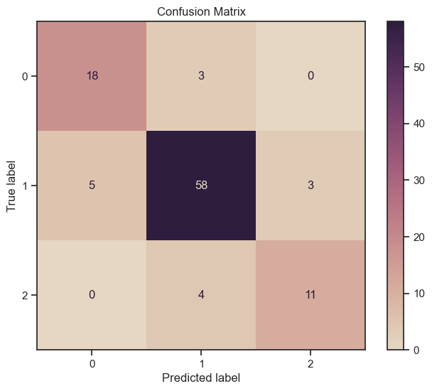

```python
DT_grid_search_params = {
    "criterion": ["gini", "entropy"],
    "splitter": ["best", "random"],
    "max_depth": range(2, 9),
    "min_samples_split": range(2, 9),
    "min_samples_leaf": range(2, 9),
    "random_state": [42],
}

DT = Classifier(DecisionTreeClassifier(), DT_grid_search_params, X_train, y_train)
DT.run(X_test, y_test)
```

### *Question 28: plotting decision tree*

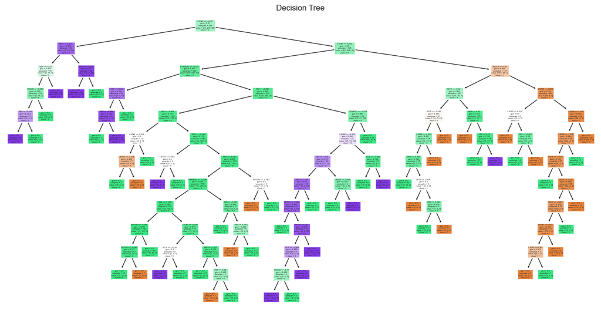

```python
DT.draw_decision_tree()
```

```
Initial model's test accuracy:  0.824
Best model's train accuracy score with grid search: 0.881
Best model's test score with grid search: 0.843
Best hyperparameters with grid search: {'metric': 'manhattan', 'n_neighbors': 5}
```

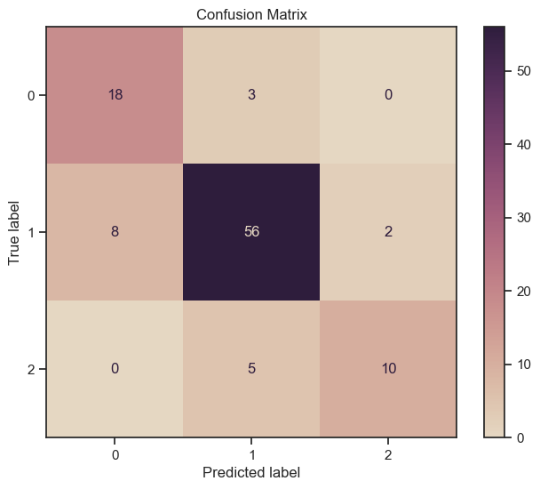

```python
KNN_grid_search_params = {
        "n_neighbors": range(1,100),
        "metric": ["euclidean", "manhattan", "minkowski"]
}
KNN = Classifier(KNeighborsClassifier(), KNN_grid_search_params, X_train, y_train)
KNN.run(X_test, y_test)
```

### *Question 29: Overfitting vs underfitting*

*To determine whether underfitting or overfitting has occurred in the models, we need to evaluate their performance on both the training and testing datasets.*

*`Underfitting`: Underfitting occurs when the model is too simple to capture the underlying patterns of the data, resulting in poor performance on both the training and testing datasets. Signs of underfitting include low accuracy or performance metrics on both datasets and a high bias. It implies that the model is not complex enough to capture the relationships in the data.*

*`Overfitting`: Overfitting occurs when the model captures noise or random fluctuations in the training data, resulting in excellent performance on the training dataset but poor performance on the testing dataset. Signs of overfitting include high accuracy or performance metrics on the training dataset but significantly lower performance on the testing dataset. It implies that the model has memorized the training data instead of learning generalizable patterns.*

*In our model we have overfitting*

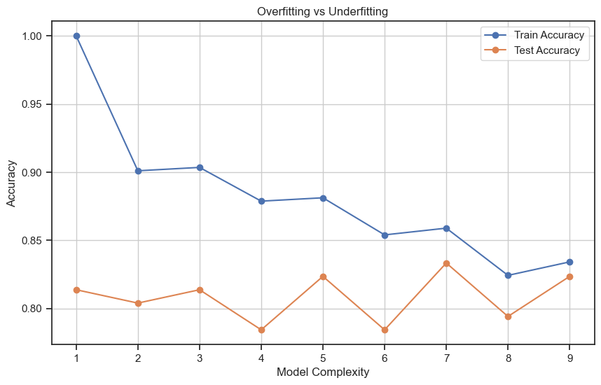

```python
train_scores = []
test_scores = []
param_range = range(1, 10)
for n_neighbors in param_range:
    knn = KNeighborsClassifier(n_neighbors=n_neighbors)
    knn.fit(X_train, y_train)
    train_scores.append(knn.score(X_train, y_train))
    test_scores.append(knn.score(X_test, y_test))

KNN.check_overfit_underfit(param_range, train_scores, test_scores)
```

## *Ensemble methods*

### *Question 30: Why ensemble methods are useful*

*Ensemble methods like bagging, boosting, and stacking have become crucial in machine learning due to their ability to improve predictive accuracy, enhance robustness, reduce overfitting, offer flexibility across various tasks, and scale effectively to large datasets. By combining multiple models' predictions, ensemble methods mitigate individual model biases and errors, resulting in more stable and accurate predictions. Their versatility and applicability to diverse types of data, coupled with advancements in computational resources, make ensemble methods indispensable in modern machine learning workflows for tackling complex and challenging predictive modeling tasks.*

### *Question 31: Boosting and Bagging*

*In bagging (Bootstrap Aggregating), multiple base learners are trained independently on different subsets of the training data, typically created through bootstrapping (sampling with replacement). The final prediction is made by averaging (for regression) or voting (for classification) the predictions of all base learners. Bagging aims to reduce variance and prevent overfitting by combining multiple models' predictions.*

*In contrast, boosting involves training multiple weak learners sequentially, with each subsequent learner focusing on the samples that the previous ones misclassified. The final prediction is a weighted sum of the predictions of all weak learners. Boosting aims to reduce bias and improve accuracy by iteratively correcting the errors made by earlier models. Unlike bagging, boosting assigns weights to training instances, emphasizing the importance of hard-to-classify examples, which can lead to a stronger overall learner.*

### *Question 32: Random Forest*

*Random Forest is an ensemble learning method that operates by constructing multiple decision trees during training and outputting the class that is the mode of the classes (classification) or mean prediction (regression) of the individual trees. Each decision tree is trained on a random subset of the training data and a random subset of the features, typically chosen without replacement. This randomness helps to decorrelate the trees and reduce overfitting. During prediction, the Random Forest aggregates the predictions of all the individual trees to make the final prediction. This ensemble approach often results in more robust and accurate predictions compared to single decision trees.*

### *Question 33: Bootstrapping in Random Forest*

*In Random Forest, bootstrapping is a technique used to create multiple subsets of the original dataset by randomly sampling with replacement. Each subset, called a bootstrap sample, has the same size as the original dataset but may contain duplicate instances and may exclude some original instances. These bootstrap samples are then used to train individual decision trees within the Random Forest ensemble.*

*Bootstrapping helps introduce diversity among the decision trees because each tree is trained on a slightly different subset of the data. This diversity is beneficial because it helps reduce overfitting and improves the overall performance of the Random Forest model. Additionally, bootstrapping allows some instances to be left out of each bootstrap sample, which can be used as "out-of-bag" (OOB) samples for estimating the model's performance without the need for a separate validation set.*

### *Question 34: Number of Decision Tress in Random Forest*

*The number of decision trees in a Random Forest significantly influences the model's performance. Generally, increasing the number of trees can lead to better performance up to a certain point, after which the improvement may plateau or even decrease due to overfitting.*

*The optimal number of trees in a Random Forest is typically determined empirically through experimentation and validation. It depends on factors such as the complexity of the dataset, the level of noise, and computational resources. In practice, a common range for the number of trees in a Random Forest is between 10 to 200.*

### *Question 35: When we should use Random Forest*

*Random Forest is not suitable in scenarios where interpretability is paramount, such as when the model's decision-making process needs to be transparent and easily understandable. Since Random Forest combines multiple decision trees, interpreting the individual trees' decisions becomes more challenging, making it less suitable for applications where interpretability is crucial, such as in legal or medical domains.*

*On the other hand, Random Forest is highly recommended when dealing with complex datasets with high-dimensional features or when robust performance is required. It excels in handling noisy data, mitigating overfitting, and providing reliable predictions, making it a preferred choice in various real-world applications, including classification and regression tasks in fields like finance, marketing, and bioinformatics. Additionally, its ability to handle large datasets efficiently and its scalability make it well-suited for big data analytics and machine learning tasks in industries with vast amounts of data.*

### *Question 36: Effect of Random Forest on Variance*

*Random Forest can help reduce the variance of a model. By combining multiple decision trees trained on different subsets of the data, Random Forest averages out the predictions of individual trees, leading to a smoother overall prediction. This averaging process tends to reduce the variance of the model compared to a single decision tree. As a result, Random Forests are less prone to overfitting, which can occur when a model captures noise or idiosyncrasies in the training data rather than learning the underlying patterns. Overall, Random Forests can provide more stable and reliable predictions by reducing variance, making them a popular choice in machine learning tasks where robustness is important.*

### *Question 37: Random Forest Hyperparameters*

*some of the most important hyperparameters of Random Forest are:*

1. *`n_estimators`: The number of decision trees in the Random Forest. A larger value of n_estimators can improve the performance of the model, but may also increase the training time and memory usage.*
2. *`criterion`: The function used to measure the quality of a split. The default is 'gini', which uses the Gini impurity measure. Another option is 'entropy', which uses the information gain measure.*
3. *`max_depth`: The maximum depth of the decision trees in the Random Forest. A larger value of max_depth can capture more complex patterns in the data, but may also lead to overfitting. A smaller value of max_depth can help prevent overfitting but may also lead to underfitting.*
4. *`min_samples_split`: The minimum number of samples required to split an internal node. A larger value of min_samples_split can help prevent overfitting but may also lead to underfitting.*
5. *`min_samples_leaf`: The minimum number of samples required to be at a leaf node. A larger value of min_samples_leaf can help prevent overfitting but may also lead to underfitting.*
6. *`max_features`: The maximum number of features to consider when making a split. The default is 'auto', which uses the square root of the number of features. Another option is 'sqrt', which uses the square root of the number of features.*
7. *`class_weight`: The weight function used in the classification. The default is None, which means all classes have equal weight. Another option is 'balanced', which automatically adjusts the weights based on the number of samples in each class.*
8. *`random_state`: Controls the randomness of the estimator. If an integer is given, the randomness will be deterministic and the results will be reproducible.*

```
Initial model's test accuracy:  0.843
Best model's train accuracy score with grid search: 0.933
Best model's test score with grid search: 0.853
Best hyperparameters with grid search: {'criterion': 'entropy', 'max_depth': 5, 'n_estimators': 320}
```

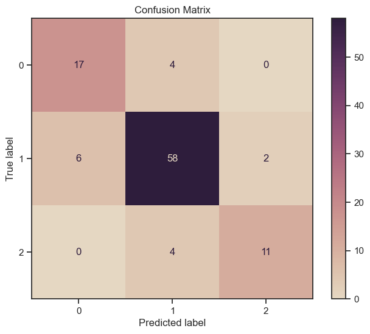

```python
RF_grid_search_params = {
            'n_estimators': range(100, 400, 20),
            'criterion': ['entropy', 'gini'],
            'max_depth': range(5, 10),
        }

RF_classifier = RandomForestClassifier()

RF = Classifier(RF_classifier, RF_grid_search_params, X_train, y_train)
RF.run(X_test, y_test)
```

```python
def hyper_param_comp(param_range, init_params, param):
    test_accs = []
    train_accs = []
    for i in param_range:
        init_params[param] = i
        classifier = RandomForestClassifier(criterion=init_params['criterion'], max_depth=init_params['max_depth'], n_estimators=init_params['n_estimators'])
        RF = Classifier(classifier, RF_grid_search_params, X_train, y_train)
        test_accs.append(RF.calc_accuracy(X_test, y_test))
        train_accs.append(RF.train_accuracy)

    plt.plot(param_range, test_accs, color='blue', label='test')
    plt.plot(param_range, train_accs, color='red', label='train')
    plt.xlabel(param)
    plt.ylabel('Accuracy')
    plt.legend(loc="lower right")
```

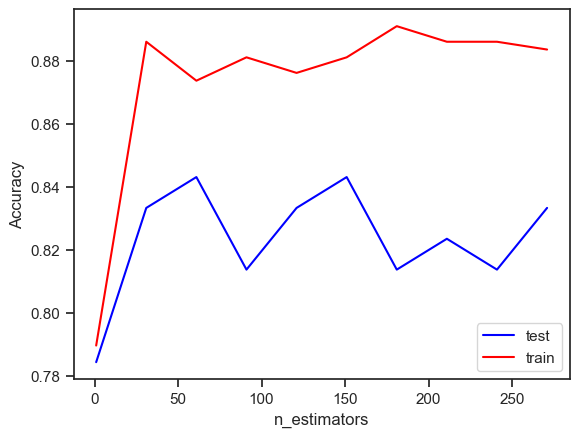

```python
params = {
        'criterion': "gini",
        'max_depth': 3,
        'min_samples_leaf': 11,
        'n_estimators': 1,
}
hyper_param_comp(range(1, 300, 30), params, 'n_estimators')
```

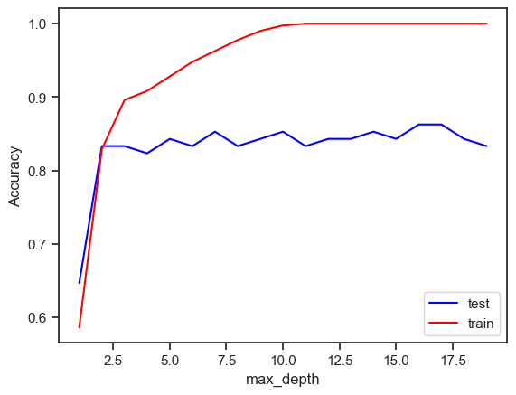

```python
params = {
        'criterion': 'gini',
        'max_depth': 1,
        'n_estimators': 40,
}
hyper_param_comp(range(1, 20), params, 'max_depth')
```

## *XGBoost*

### *Question 38: what is XGBoost*

*XGBoost, short for Extreme Gradient Boosting, is an efficient and scalable implementation of gradient boosting framework. It works by sequentially adding weak learners (decision trees) to the ensemble, where each subsequent learner corrects the errors made by the previous ones. XGBoost optimizes a loss function by employing gradient descent algorithm and regularization techniques to prevent overfitting. It utilizes parallel computing and tree pruning algorithms to enhance computational speed and model accuracy. Overall, XGBoost is known for its high performance, versatility, and ability to handle large-scale datasets across various machine learning tasks such as classification, regression, and ranking.*

### *Question 39: Gradient-Boosting*

*Gradient boosting is a popular machine learning technique for building predictive models. It involves combining multiple weak models, typically decision trees, to create a strong ensemble model. The basic idea is to fit a sequence of simple models to the residuals of the previous model, with the objective of minimizing a loss function. This process continues until a stopping criterion is met, such as a maximum number of iterations or a minimum improvement in the loss function.*

***Boosting Tree vs Decision Tree:***

- ***Ensemble vs. Single Model:*** *Boosting tree is an ensemble learning algorithm that combines multiple weak learners (usually decision trees) into a strong learner, while decision tree is a single model that makes predictions based on a single tree-like structure.*
- ***Iterative vs. Non-Iterative:*** *Boosting tree is an iterative algorithm that adds new trees to the ensemble iteratively, with each new tree attempting to correct the errors of the previous trees, while decision tree is a non-iterative algorithm that constructs a single tree-like structure based on the input features.*
- ***Bias-Variance Tradeoff:*** *Boosting tree is designed to reduce both bias and variance, by combining multiple weak learners into a strong learner that can make accurate predictions on new, unseen data, while decision tree is prone to overfitting, especially when the tree is too deep or the number of training samples is too small.*
- ***Hyperparameters:*** *Boosting tree has several hyperparameters that can be tuned to improve its performance, such as the learning rate, the number of trees in the ensemble, the maximum depth of each tree, and the minimum number of samples required to split a node, while decision tree has fewer hyperparameters, such as the maximum depth of the tree, the minimum number of samples required to split a node, and the splitting criterion.*
- ***Interpretability:*** *Decision tree is more interpretable than boosting tree, because it produces a single tree-like structure that can be easily visualized and understood, while boosting tree produces an ensemble of trees that can be more difficult to interpret.*

```
Initial model's test accuracy:  0.843
Best model's train accuracy score with grid search: 0.965
Best model's test score with grid search: 0.824
Best hyperparameters with grid search: {'gamma': 0, 'learning_rate': 0.1, 'max_depth': 3, 'n_estimators': 80}
```

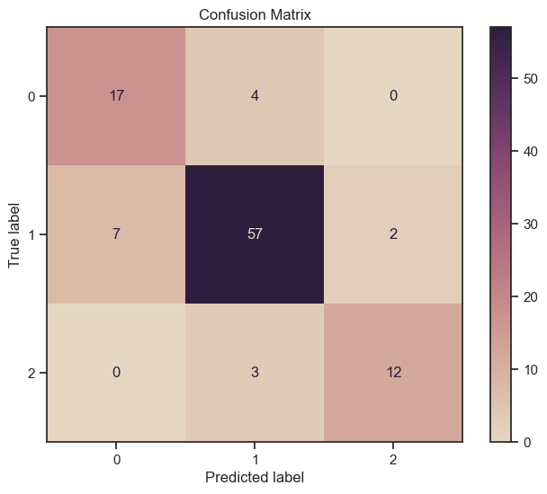

```python
XGB_grid_search_params = {
    'max_depth': range(3,11,2),
    'learning_rate': [0.01, 0.03, 0.09, 0.1],
    'n_estimators': range(20,201,30),
    'gamma': [0, 1, 10, 100]
}
XGB = Classifier(XGBClassifier(), XGB_grid_search_params, X_train, y_train)
XGB.run(X_test, y_test)
```

## *Support Vector Machine*

```
Evaluation for SVM with RBF Kernel:
Initial model's test accuracy:  0.794
Best model's train accuracy score with grid search: 0.876
Best model's test score with grid search: 0.814
Best hyperparameters with grid search: {'C': 100, 'gamma': 0.1}
```

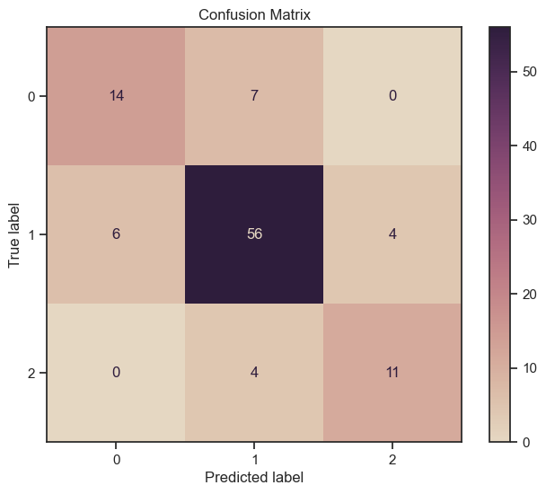

```python
svm_rbf_grid_search_params = {
    'C': [0.1, 1, 10, 100],
    'gamma': [0.1, 0.01, 0.001, 0.0001],
}
svm_rbf = Classifier(SVC(kernel='rbf'), svm_rbf_grid_search_params, X_train, y_train)
print("Evaluation for SVM with RBF Kernel:")
svm_rbf.run(X_test, y_test)
```

```
Evaluation for SVM with Linear Kernel:
Initial model's test accuracy:  0.804
Best model's train accuracy score with grid search: 0.834
Best model's test score with grid search: 0.814
Best hyperparameters with grid search: {'C': 100}
```

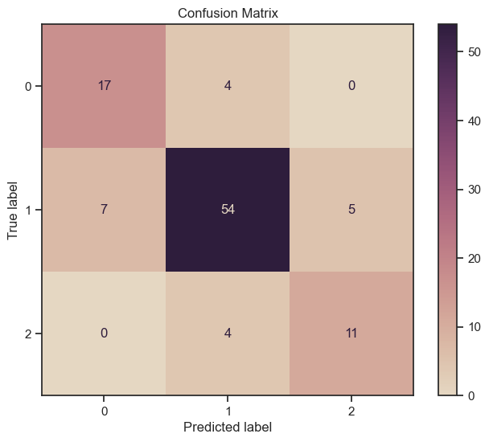

```python
svm_linear_grid_search_params = {
    'C': [0.1, 1, 10, 100],
}
svm_linear = Classifier(SVC(kernel='linear'), svm_linear_grid_search_params, X_train, y_train)
print("\nEvaluation for SVM with Linear Kernel:")
svm_linear.run(X_test, y_test)
```

```
Evaluation for SVM with RBF Kernel:
Initial model's test accuracy:  0.794
Best model's train accuracy score with random search: 0.921
Best model's test score with random search: 0.794
Best hyperparameters with random search: {'gamma': 0.071, 'C': 875.1}
```

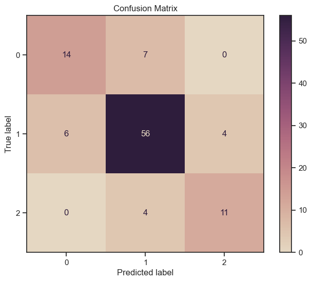

```python
svm_rbf_random_search_params = {
    'C': np.arange(0.1,1000,0.5),
    'gamma': np.arange(0.001,0.1,0.01),
}
svm_rbf = Classifier(SVC(kernel='rbf'), svm_rbf_grid_random_params, X_train, y_train)
print("Evaluation for SVM with RBF Kernel:")
svm_rbf.run(X_test, y_test,'random')
```

```
Evaluation for SVM with linear Kernel:
Initial model's test accuracy:  0.804
Best model's train accuracy score with random search: 0.829
Best model's test score with random search: 0.814
Best hyperparameters with random search: {'C': 776.6}
```

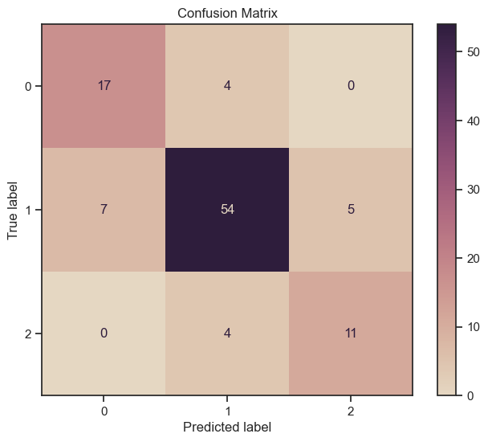

```python
svm_linear_random_search_params = {
    'C': np.arange(0.1,1000,0.5),
}
svm_linear = Classifier(SVC(kernel='linear'), svm_linear_random_search_params, X_train, y_train)
print("Evaluation for SVM with linear Kernel:")
svm_linear.run(X_test, y_test,'random')
```

### *Question 40.3: Random vs Grid search*

*Considering our dataset's size, Grid Search is preferable for efficiently finding optimal hyperparameters within a short timeframe, while Random Search is more suitable for larger datasets.*

## *Evaluation*

*I have performed evaluations for models such as K-Nearest Neighbors (KNN), Decision Trees, Support Vector Machines (SVM), and Random Forests (RF).*

```python
DT_search_params = {
    "criterion": "entropy",
    "splitter": "best",
    "max_depth": 6,
    "min_samples_split": 5,
    "min_samples_leaf": 2,
    "random_state": [42],
}

DT = Classifier(DecisionTreeClassifier(), DT_search_params, X_train, y_train)
DT.print_metrics(X_test, y_test)
```

```
Metrics for average method: micro
Accuracy: 0.814
Precision: 0.814
Recall: 0.814
F1 Score: 0.814

Metrics for average method: macro
Accuracy: 0.814
Precision: 0.778
Recall: 0.786
F1 Score: 0.778

Metrics for average method: weighted
Accuracy: 0.814
Precision: 0.821
Recall: 0.814
F1 Score: 0.814
```

```python
KNN_search_params = {
        "n_neighbors": 5,
        "metric":"manhattan",
}
KNN = Classifier(KNeighborsClassifier(), KNN_search_params, X_train, y_train)
KNN.print_metrics(X_test, y_test)
```

```
Metrics for average method: micro
Accuracy: 0.824
Precision: 0.824
Recall: 0.824
F1 Score: 0.824

Metrics for average method: macro
Accuracy: 0.824
Precision: 0.800
Recall: 0.791
F1 Score: 0.789

Metrics for average method: weighted
Accuracy: 0.824
Precision: 0.831
Recall: 0.824
F1 Score: 0.824
```

```python
param = {
    'criterion': 'entropy',
    'max_depth': 5,
    'n_estimators': 320,
    }

RF = Classifier(RF_classifier, RF_grid_search_params, X_train, y_train)
RF.print_metrics(X_test, y_test)
```

```
Metrics for average method: micro
Accuracy: 0.863
Precision: 0.863
Recall: 0.863
F1 Score: 0.863

Metrics for average method: macro
Accuracy: 0.863
Precision: 0.846
Recall: 0.817
F1 Score: 0.830

Metrics for average method: weighted
Accuracy: 0.863
Precision: 0.862
Recall: 0.863
F1 Score: 0.862
```

```python
svm_rbf_grid_search_params = {
    'C': 100,
    'gamma': 0.1,
}
svm_rbf = Classifier(SVC(kernel='rbf'), svm_rbf_params, X_train, y_train)
svm_rbf.print_metrics(X_test,y_test)
```

```
Metrics for average method: micro
Accuracy: 0.794
Precision: 0.794
Recall: 0.794
F1 Score: 0.794

Metrics for average method: macro
Accuracy: 0.794
Precision: 0.756
Recall: 0.749
F1 Score: 0.753

Metrics for average method: weighted
Accuracy: 0.794
Precision: 0.793
Recall: 0.794
F1 Score: 0.793
```

```python
svm_linear_params = {
    'C': 100,
}

svm_linear = Classifier(SVC(kernel='linear'), svm_linear_params, X_train, y_train)
svm_linear.print_metrics(X_test, y_test)
```

```
Metrics for average method: micro
Accuracy: 0.804
Precision: 0.804
Recall: 0.804
F1 Score: 0.804

Metrics for average method: macro
Accuracy: 0.804
Precision: 0.756
Recall: 0.787
F1 Score: 0.770

Metrics for average method: weighted
Accuracy: 0.804
Precision: 0.811
Recall: 0.804
F1 Score: 0.806
```